# Google analytics

Ignacio

27/4/2022

[figure not shown]

# Google Analytics project: How Can a Wellness Technology Company Play It Smart?

For this project we will analyze data for a wellness technology company in order to help them take informed decitions. We will follow the 6 steps of data analysis from the Google Analytics course: Ask, Prepare, Process, Analyse, Share and Act.

# 1 Ask

Bellabeat is a health smart product, marketed for women, to inspire and empower them with knowledge of their health and habits. The company wants us to analyze smart device usage to gain consumer use knowledge. We then need to apply that onto a selected Bellabeat product.

The main questions are:

1. What are some trends in smart device usage?
2. How could these trends apply to Bellabeat customers?
3. How could these trends help influence Bellabeat marketing strategy?

# 2 Prepare

In order to answer the main questions we are encouraged to use publicly available data from smart device users.

- The data selected for this project is the FitBit Fitness Tracker Data (CC0: Public Domain, dataset made available through Möbius).
- In this dataset 30 FitBit users consented to the submission of their personal tracker data, including minute-level output for physical activity, heart rate, sleep monitoring and weight tracking.
- The data comprehends a month of use of the tracker, beween 12th of April and 12th of May, 2016.
- There is a variability in the output collected due to the different type of FitBit tracker and the individual tracking preference.

Using the ROCCC method to assess the credibility of the data:

**R**eliable: The data presents different formats (due to different trackers), it is not complete (different tracking preferences) and one of the files presents repeated values.

**O**riginal: The data comes from a third party provider.

**C**omprehensive: The parameters measured are quite comprehensive when it comes to a fitness device tracker. However, it only includes 30 participants.

**C**urrent: The data is from 2016. We would not expect a change in the overall health of the population measured by the devices since, but maybe an improvement in the devices or the parameters they can measure.

**C**ited: As a third party data we have no information regarding a credible source.

# 3 Process

As the Google Analytics course focuses on R as the programming language, I will use it for the further analysis.

```r
library(tidyverse)
library(lubridate)
library(data.table)
library(ggpmisc)
library(patchwork)

daily_activity <- read.csv("dailyActivity_merged.csv")
weight_log <- read.csv("weightLogInfo_merged.csv")
sleep_day <- read.csv("sleepDay_merged.csv")
```

Converting Date and time value to a correct datetime format and added weekday name for more information

```r
Sys.setlocale("LC_TIME", "C")
```

```
## [1] "C"
```

```r
daily_activity <- mutate(daily_activity, ActivityDate = mdy(ActivityDate))
daily_activity <- daily_activity %>% mutate(weekday = weekdays(ActivityDate))
daily_activity$weekday <- ordered(daily_activity$weekday, levels=c("Monday", "Tuesday", "Wednesday", "Thursday","Friday", "Saturday", "Sunday"))
sleep_day <- mutate(sleep_day, Date = mdy_hms(SleepDay))
sleep_day <- sleep_day %>% mutate(weekday = weekdays(Date))
sleep_day$weekday <- ordered(sleep_day$weekday, levels=c("Monday", "Tuesday", "Wednesday", "Thursday","Friday", "Saturday", "Sunday"))
weight_log <- mutate(weight_log, Date = mdy_hms(Date))
weight_log <- weight_log %>% mutate(weekday = weekdays(Date))
weight_log$weekday <- ordered(weight_log$weekday, levels=c("Monday", "Tuesday", "Wednesday", "Thursday","Friday", "Saturday", "Sunday"))

weight_log <- mutate(weight_log, Time = format(Date, "%H:%M:%S"))
weight_log <- mutate(weight_log, Date = format(Date, "%Y-%m-%d"))
```

### Data summary

```r
#Added a palet of colors for the graphs
cbPalette <- c("#999999", "#E69F00", "#56B4E9", "#009E73", "#F0E442", "#0072B2", "#D55E00", "#CC79A7")

merge_act_sleep_weight <-unique(merge(daily_activity, sleep_day, by.x = c("Id","ActivityDate"),by.y=c("Id","Date"), all=TRUE) %>%  merge(weight_log, by.x = c("Id","ActivityDate"),by.y=c("Id","Date"),all=TRUE))
merge_act_sleep_weight %>%
  select(Diastance = TotalDistance,Steps = TotalSteps, Calories, SedentaryTime = SedentaryMinutes, Sleep_minutes = TotalMinutesAsleep, WeightKg, BMI) %>%
  summary()
```

```
##    Diastance          Steps          Calories    SedentaryTime
##  Min.   : 0.000   Min.   :    0   Min.   :   0   Min.   :   0.0
##  1st Qu.: 2.620   1st Qu.: 3790   1st Qu.:1828   1st Qu.: 729.8
##  Median : 5.245   Median : 7406   Median :2134   Median :1057.5
##  Mean   : 5.490   Mean   : 7638   Mean   :2304   Mean   : 991.2
##  3rd Qu.: 7.713   3rd Qu.:10727   3rd Qu.:2793   3rd Qu.:1229.5
##  Max.   :28.030   Max.   :36019   Max.   :4900   Max.   :1440.0
##
##  Sleep_minutes      WeightKg           BMI
##  Min.   : 58.0   Min.   : 52.60   Min.   :21.45
##  1st Qu.:361.0   1st Qu.: 61.40   1st Qu.:23.96
##  Median :432.5   Median : 62.50   Median :24.39
##  Mean   :419.2   Mean   : 72.04   Mean   :25.19
##  3rd Qu.:490.0   3rd Qu.: 85.05   3rd Qu.:25.56
##  Max.   :796.0   Max.   :133.50   Max.   :47.54
##  NA's   :530     NA's   :873      NA's   :873
```

#### Distribution of the data from a daily tracking

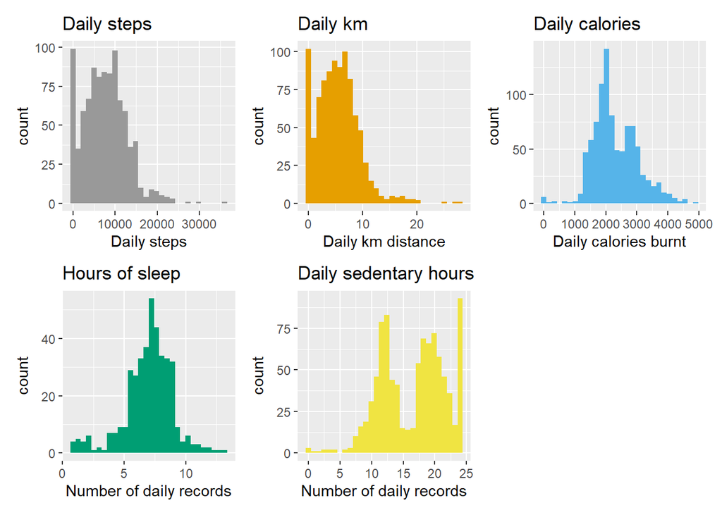

Fig 1. Histogram distribution

```r
p1 <- merge_act_sleep_weight %>% ggplot() + geom_histogram(aes(x=TotalSteps),fill = cbPalette[1]) + labs(title = "Daily steps", x="Daily steps")
p2 <- merge_act_sleep_weight %>% ggplot() + geom_histogram(aes(x=TotalDistance),fill = cbPalette[2]) + labs(title = "Daily km", x="Daily km distance")
p3 <- merge_act_sleep_weight %>% ggplot() + geom_histogram(aes(x=Calories),fill = cbPalette[3]) + labs(title = "Daily calories", x="Daily calories burnt")
p4 <- merge_act_sleep_weight %>% ggplot() + geom_histogram(aes(x=TotalMinutesAsleep/60),fill = cbPalette[4]) + labs(title = "Hours of sleep", x="Number of daily records")
p5 <- merge_act_sleep_weight %>% ggplot() + geom_histogram(aes(x=SedentaryMinutes/60),fill = cbPalette[5]) + labs(title = "Daily sedentary hours", x="Number of daily records")
p1+p2+p3+p4 +p5
```

We can see in this summary the distribution from some of the data which can lead us to some preliminary conclusions.

- We can see a correlation between steps and distance in the histogram plots.
- The average steps recommended for adults is 10000 according to the CDC, being about 8km. According to this data the average among the participants is 7638 steps and 5.49 km, way below that recommendation.
- On the same note, the time the users have spent in inactivity is 991 minutes in average a day, more than 16.5 hours.
- The average sleep recorded is og 419.2 minuts, about 7 hours.
- We can see the presence of NA’s in the merge data for sleep and weight, meaning that many of the participants don’t present daily records of those activities.

### Data completness

```r
#Performing a pivot table to check if there's step activity for each user each day
pivot_daily_steps <- daily_activity %>%  select(Id,ActivityDate,TotalSteps) %>% pivot_wider(names_from = ActivityDate, values_from=TotalSteps, values_fill = NaN)
pivot_daily_steps$num_na <- rowSums(is.na(pivot_daily_steps))
pivot_daily_steps %>% select(Id,num_na) %>%  arrange(desc(num_na))
```

```
## # A tibble: 33 x 2
##            Id num_na
##         <dbl>  <dbl>
##  1 4057192912     27
##  2 2347167796     13
##  3 8253242879     12
##  4 3372868164     11
##  5 6775888955      5
##  6 7007744171      5
##  7 6117666160      3
##  8 6290855005      2
##  9 8792009665      2
## 10 1644430081      1
## # ... with 23 more rows
```

From the daily activity there is one user that only has 4 days with recorded data and 27 missing values.

#### Data recorded per activity

We can see here how much of the data was recorded from the users in the 30 day period.

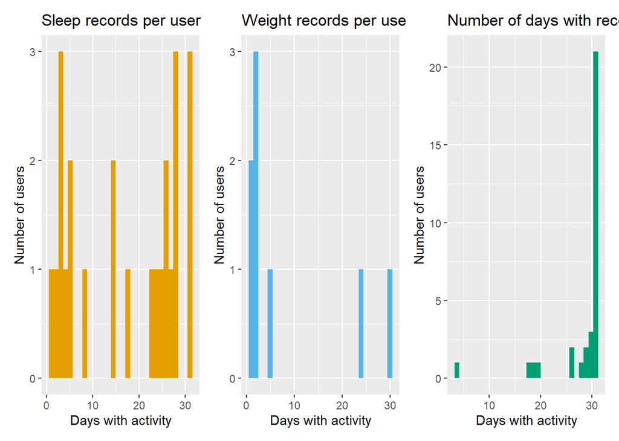

Fig 2. Number of days with activity tracked

```r
p1 <- unique(sleep_day) %>%  group_by(Id) %>% summarise(n= n()) %>% ggplot(aes(x=n)) + geom_histogram(fill = cbPalette[2]) + labs(title = "Sleep records per user") + xlab("Days with activity") + ylab("Number of users")
p2 <- weight_log %>% group_by(Id) %>% summarise(n=n()) %>% ggplot(aes(x=n)) + geom_histogram(fill = cbPalette[3]) + labs(title = "Weight records per user") + xlab("Days with activity") + ylab("Number of users")
daily_min_pivot <- daily_activity %>%  group_by(Id,ActivityDate) %>%  summarise(min_record = sum(SedentaryMinutes+LightlyActiveMinutes+FairlyActiveMinutes+VeryActiveMinutes))
p3 <- daily_min_pivot %>%  group_by(Id) %>% summarise(daily_use = mean(min_record), n=n()) %>%  arrange(n)  %>%  ggplot(aes(x=n)) + geom_histogram(fill = cbPalette[4]) + labs(title = "Number of days with recorded activity per user") + xlab("Days with activity") + ylab("Number of users")

p1+p2+p3
```

We can see as most of the participants have recorded steps, calories and activity for most of the month time, the recorded weight and sleep is not kept as precise.

#### Weight track

We can see from the histogram in Fig 2 that the weight is tracked by the least amount of users with only 8 participants.

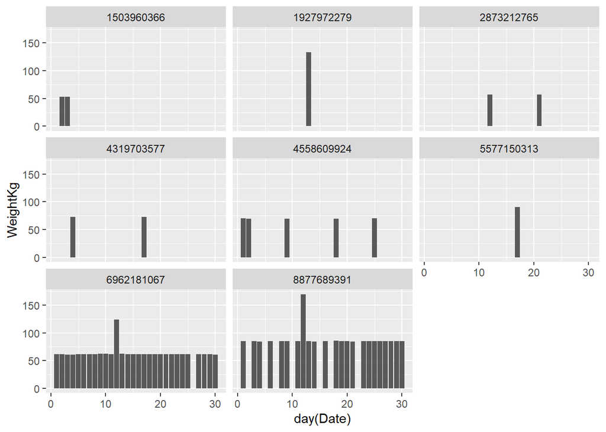

Fig 3. Weight tracking per user, per day

```r
weight_log %>%  ggplot(aes(x=day(Date),y=WeightKg)) + geom_col() + facet_wrap(~Id)
```

- Only 8 out of 30 participants have a minimum of 1 weight input
- Only 1 of those 8 uses an automatic method for a periodic input of weight.
- Only 2 of those 8 have more than 5 weight inputs in 30 days.

# 4 Analyse and Share

### Study the correlation between steps, distance and calories

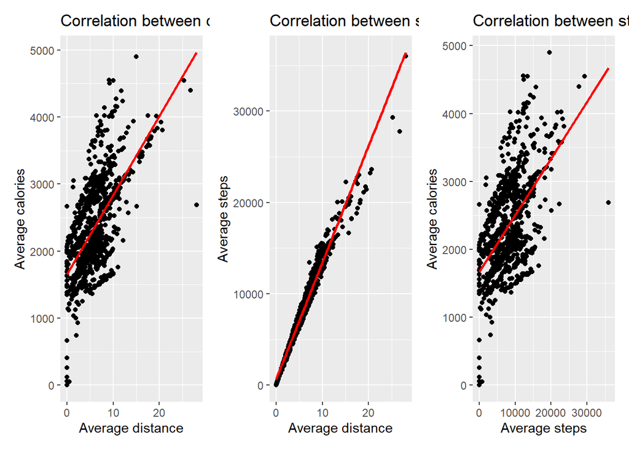

Fig 4. Correlation between calories, distance and steps

```r
p1 <- daily_activity %>%
  ggplot(aes(x=TotalDistance,y=Calories)) + geom_point() + labs(title = "Correlation between calories and distance") + xlab("Average distance") + ylab("Average calories") +geom_smooth(method=lm, se=FALSE, col='red', size=1)
p2 <- daily_activity %>%
  ggplot(aes(x=TotalDistance,y=TotalSteps)) + geom_point() + labs(title = "Correlation between steps and distance") + xlab("Average distance") + ylab("Average steps") +geom_smooth(method=lm, se=FALSE, col='red', size=1)
p3 <- daily_activity %>%
  ggplot(aes(x=TotalSteps,y=Calories)) + geom_point() + labs(title = "Correlation between steps and calories") + xlab("Average steps") + ylab("Average calories") +geom_smooth(method=lm, se=FALSE, col='red', size=1)
p1+p2+p3
```

As speculated before, there is a strong correlation between steps and distance. This correlation is not as strong between steps and distance with the calories.

### Distribution of time per intensity

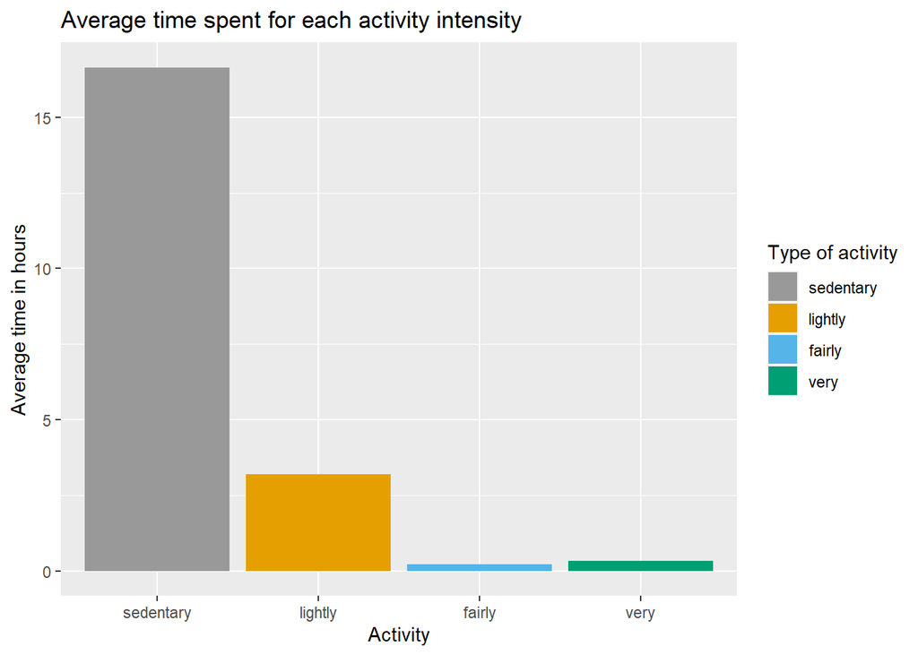

Fig 5. Intensity distribution throughout the day

```r
#Type of activity in average from all users
daily_pivot <- daily_activity %>%  group_by(Id) %>% summarise(sedentary=mean(SedentaryMinutes),lightly=mean(LightlyActiveMinutes),fairly = mean(FairlyActiveMinutes),very=mean(VeryActiveMinutes))

daily_pivot <- as.data.frame(melt(as.data.table(daily_pivot),id.vars= "Id",variable.name = "category", value.name = "value"))

daily_pivot %>%  group_by(category) %>% summarise(mean=mean(value)) %>% ggplot(aes(x=category,y=mean/60, fill=category)) + geom_bar(position="dodge", stat = "identity") + labs(title = "Average time spent for each activity intensity", x="Activity", y="Average time in hours") + scale_fill_manual(name="Type of activity", values = cbPalette)
```

The distribution of time used per activity intensity is very much skewed to the sedentary activity, with an average of 16 hours, with very little time used for fairly active or very active excersise.

### User clustering by average steps

From the participants we can group them according to their average steps in 4 different categories to further study this: Bellow 5000 steps: Sedentary Between 5000 and 8000 steps: Lightly active Between 8000 and 10000 steps: Fairly active Above 10000 steps: Very active

```r
daily_activity %>% group_by(Id) %>%filter(Id!=4057192912) %>%  summarise(mean_steps = mean(TotalSteps), mean_distance = mean(TotalDistance), distance_per_step = mean(TotalDistance)*1000/mean(TotalSteps),n=n()) %>% arrange(n)
```

```
## # A tibble: 32 x 5
##            Id mean_steps mean_distance distance_per_step     n
##         <dbl>      <dbl>         <dbl>             <dbl> <int>
##  1 2347167796      9520.          6.36             0.668    18
##  2 8253242879      6482.          4.67             0.720    19
##  3 3372868164      6862.          4.71             0.686    20
##  4 6775888955      2520.          1.81             0.720    26
##  5 7007744171     11323.          8.02             0.708    26
##  6 6117666160      7047.          5.34             0.758    28
##  7 6290855005      5650.          4.27             0.756    29
##  8 8792009665      1854.          1.19             0.640    29
##  9 1644430081      7283.          5.30             0.727    30
## 10 3977333714     10985.          7.52             0.684    30
## # ... with 22 more rows
```

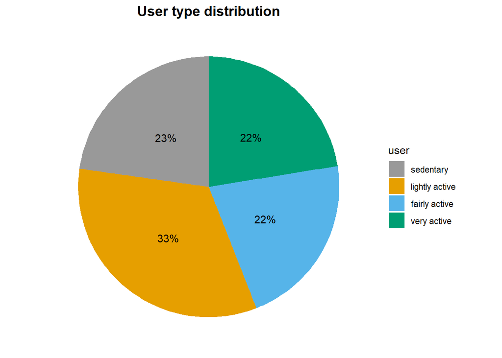

Fig 6. Distribution of the type of users based on their average steps

```r
daily_active <- unique(daily_activity) %>% group_by(Id) %>%  summarise(mean_steps = mean(TotalSteps), mean_distance = mean(TotalDistance), mean_calories = mean(Calories),sd_step = sd(TotalSteps), sd_distance=sd(TotalDistance),sd_calories = sd(Calories),n=n()) %>% arrange(n) %>% mutate(user = case_when(
  mean_steps >= 10000~"very active", mean_steps < 10000 & mean_steps >=8000~"fairly active", mean_steps <8000 & mean_steps>=5000~"lightly active", mean_steps <5000~"sedentary"
)) %>% merge(daily_activity,by="Id")
daily_active$user <- ordered(daily_active$user, levels=c("sedentary", "lightly active", "fairly active", "very active"))

daily_active %>%  group_by(user) %>%  summarise(n=n(), labels = paste(toString(round((n/940)*100)),"%",sep="")) %>% ggplot(aes(x="", y=n, fill=user)) + geom_bar(stat = "identity", width = 1) +coord_polar("y", start=0) + theme_minimal() + theme(axis.title.x= element_blank(), axis.title.y = element_blank(), panel.border = element_blank(), panel.grid = element_blank(), axis.ticks = element_blank(), axis.text.x = element_blank(), plot.title = element_text(hjust = 0.5, size=14, face = "bold")) +scale_fill_manual(values =cbPalette) +geom_text(aes(label = labels), position = position_stack(vjust = 0.5))+ labs(title="User type distribution")
```

#### After clustering by average steps, we can see if we find any pattern for activity level.

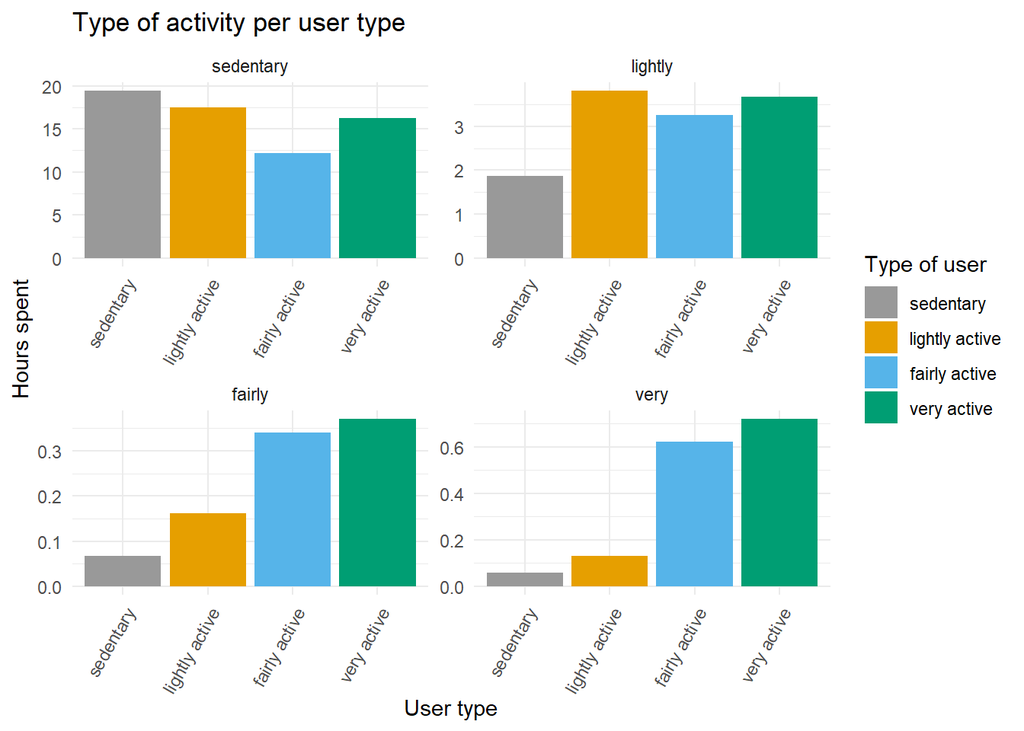

Fig 7. Intensity level per user type

```r
daily_pivot2 <- daily_active %>%  group_by(user) %>% arrange(mean_steps) %>% summarise(sedentary=mean(SedentaryMinutes)/60,lightly=mean(LightlyActiveMinutes)/60,fairly = mean(FairlyActiveMinutes)/60,very=mean(VeryActiveMinutes)/60) %>% arrange()
daily_pivot2 <- as.data.frame(melt(as.data.table(daily_pivot2),id.vars= "user",variable.name = "category", value.name = "value"))
daily_pivot2 %>% mutate(name= fct_relevel(user,"sedentary","lightly active","fairly active","very active")) %>% ggplot(aes(x=name,y=value, fill=name)) + geom_bar(position="dodge", stat = "identity") + facet_wrap(~category, scales = "free") +theme_minimal() + labs(title="Type of activity per user type", x= "User type", y= "Hours spent") +  scale_fill_manual(name="Type of user", values = cbPalette) + theme(axis.text.x = element_text(angle = 60, vjust = 1, hjust=1))
```

#### Activity per weeekday

After that we can hypothesize if there is any correlation in tracking data according to the day of the week.

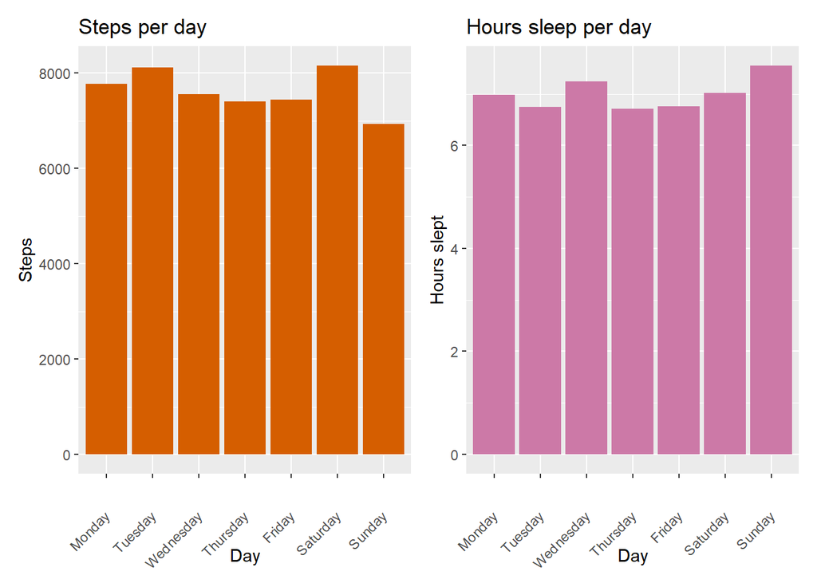

Fig 8. Recorded steps and sleep per weekday

```r
p1 <- daily_active %>% group_by(weekday) %>% summarise(mean_steps = mean(TotalSteps)) %>% ggplot(aes(x=weekday,y=mean_steps)) + geom_col(fill=cbPalette[7]) +theme(axis.text.x = element_text(angle = 45,vjust = 0.5, hjust = 1)) +labs(title="Steps per day", x= "Day", y="Steps")
p2 <- sleep_day %>% group_by(weekday) %>% summarise(mean_sleep = mean(TotalMinutesAsleep)/60) %>% ggplot(aes(x=weekday,y=mean_sleep)) + geom_col(fill=cbPalette[8]) +theme(axis.text.x = element_text(angle = 45,vjust = 0.5, hjust = 1)) +labs(title="Hours sleep per day", x= "Day", y="Hours slept")
p1+p2
```

Interestingly, but maybe not surprising, Sundays are the days with less steps and more hours of sleep.

Checking the sleep record we see only 15 participants (out of 33) have records with more 10 or more days of sleep recorded from the 30 possible. There is also 9 users with less than 9 records, and other 9 with no sleep record from their FitBit. Only considering the regular users, we see an average sleep time of 7 hours and 16 minutes, with a standard deviation of 53 minutes.

#### Activity distribution along the day

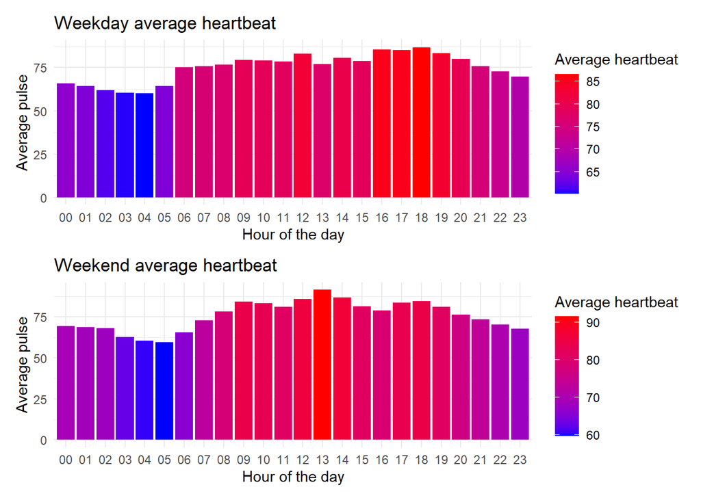

Fig 9. Intensity along the day

```r
heartrate_seconds <- read.csv("heartrate_seconds_merged.csv")
heartrate_seconds <- mutate(heartrate_seconds, Time = mdy_hms(Time))
heartrate_seconds  <- heartrate_seconds  %>% mutate(weekday = weekdays(Time))
heartrate_seconds$weekday <- ordered(heartrate_seconds$weekday, levels=c("Monday", "Tuesday", "Wednesday", "Thursday","Friday", "Saturday", "Sunday"))

weekday_p <- heartrate_seconds %>% filter(weekday==c("Monday","Tuesday","Wednesday", "Thursday","Friday")) %>% group_by(hour=format(Time,"%H")) %>% summarise(n(), mean_val=mean(Value)) %>% ggplot(aes(x=hour,y=mean_val, fill=mean_val)) + geom_col() + labs(title = "Weekday average heartbeat",x="Hour of the day",y="Average pulse") + theme_minimal() +scale_fill_gradient(name="Average heartbeat",low = "blue", high = "red")

weekend_p <- heartrate_seconds %>% filter(weekday==c("Saturday","Sunday")) %>%  group_by(hour=format(Time,"%H")) %>% summarise(n(), mean_val=mean(Value)) %>%   ggplot(aes(x=hour,y=mean_val, fill=mean_val)) + geom_col() + labs(title = "Weekend average heartbeat", x="Hour of the day",y="Average pulse") + theme_minimal() +scale_fill_gradient(name="Average heartbeat",low = "blue", high = "red")

weekday_p / weekend_p
```

#### Sleep tracking from users

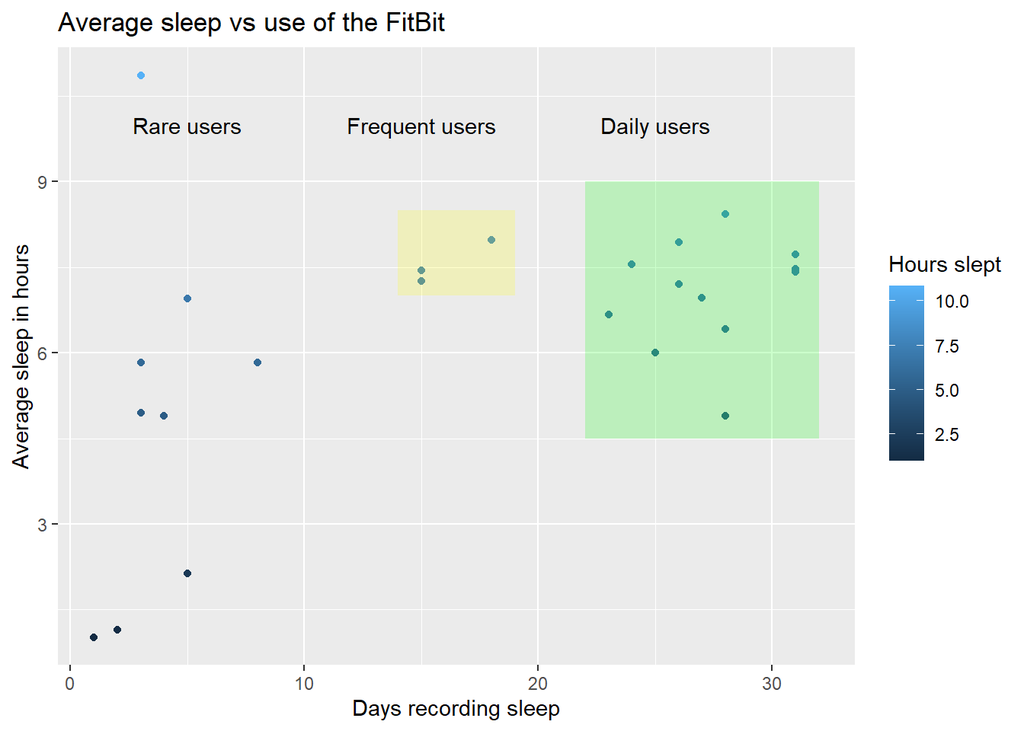

Fig 10. Sleep track per user

```r
#sleep_day %>%  ggplot(aes(x=TotalTimeInBed,y=TotalMinutesAsleep)) + geom_point() + facet_wrap(~Id)

unique(sleep_day) %>% group_by(Id) %>% summarise(sleep = mean(TotalMinutesAsleep), n=n()) %>% ggplot(aes(x=n,y=sleep/60, color=sleep/60)) + geom_point() + annotate("text",x=25, y=10 ,label = "Daily users") + annotate("rect",xmin=22, xmax=32,ymin=4.5, ymax=9, alpha=0.2, fill="Green") + annotate("text",x=15, y=10 ,label = "Frequent users") + annotate("rect",xmin=14, xmax=19,ymin=7, ymax=8.5, alpha=0.2, fill="Yellow") + annotate("text", x=5, y=10, label = "Rare users") + labs(title = "Average sleep vs use of the FitBit", color="Hours slept") + xlab("Days recording sleep") + ylab("Average sleep in hours")
```

#### Use of the tracker for activity, sleep and weight, according to the average step count

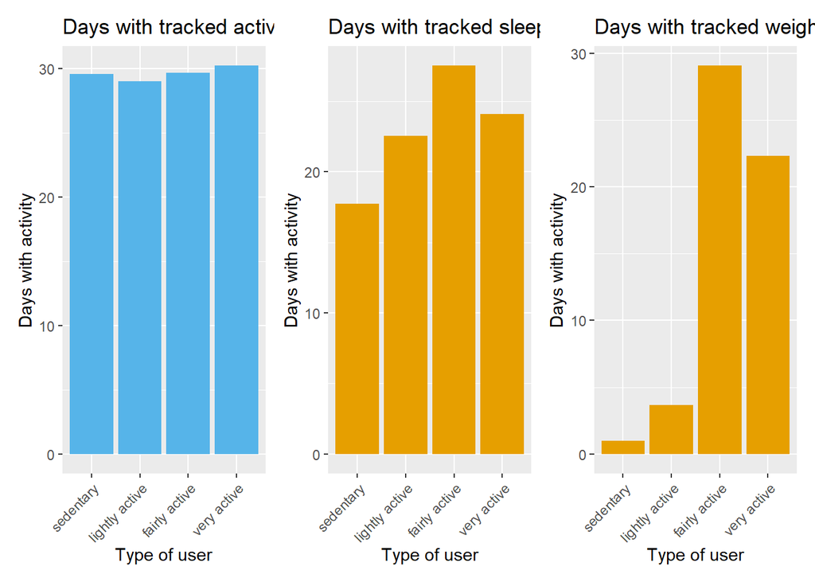

Fig 11. Tracking amount per type of user

```r
p1 <- daily_active %>%  group_by(Id) %>% summarise(n=n(), user ) %>% group_by(user) %>% summarise(mean_days=mean(n))  %>% ggplot(aes(x=user,y=mean_days)) + geom_col(fill=cbPalette[3]) + labs(title="Days with tracked activity by user's activity", x="Type of user", y="Days with activity") + theme(axis.text.x = element_text(angle = 45,vjust = 1, hjust = 1))
merge_act_sleep_weight <-unique(merge(daily_active, sleep_day, by.x = c("Id","ActivityDate"),by.y=c("Id","Date"), all=TRUE) %>%  merge(weight_log, by.x = c("Id","ActivityDate"),by.y=c("Id","Date"),all=TRUE))
p2 <- merge_act_sleep_weight[!is.na(merge_act_sleep_weight$TotalMinutesAsleep),] %>% group_by(Id) %>% summarise(n= n(),user) %>% group_by(user) %>% summarise(mean_sleep = mean(n)) %>% ggplot(aes(x=user,y=mean_sleep)) + geom_col(fill=cbPalette[2]) + labs(title="Days with tracked sleep by user's activity", x="Type of user", y="Days with activity") + theme(axis.text.x = element_text(angle = 45,vjust = 1, hjust = 1))
p3 <- merge_act_sleep_weight[!is.na(merge_act_sleep_weight$WeightKg),] %>% group_by(Id) %>% summarise(n= n(),user) %>% group_by(user) %>% summarise(mean_weight = mean(n)) %>% ggplot(aes(x=user,y=mean_weight)) + geom_col(fill=cbPalette[2]) + labs(title="Days with tracked weight by user's activity", x="Type of user", y="Days with activity") + theme(axis.text.x = element_text(angle = 45,vjust = 1, hjust = 1))

p1+p2+p3
```

While we don’t see a major difference in the amount of tracked data for daily steps according to the user activity, we do see a difference in the sleep tracking. Users that have a more sedentary life have a tendency to track less their sleep.

## 5 Act

As early mentioned, Bellabeat is a company that has since 2013 contributed into empowering women giving them knowledge about their activity, sleep, stress and reproductive health. After analyzing data from a 3rd party source from a smart tracker, we can present some conclusions regarding our analysis.

3 - While Bellabeat claims to inform their users about stress, there was no calculated parameter for stress in the data analyzed from FitBit users. Stress could be potentially calculated with the differential increase in heartbeat, together with the pedometer track. Implementing a stress alert could be an improvement on the device that could separate them from their competitors in the market.

4 - Last but not least, when it comes to women reproductive health we cannot forget the menstrual cycle. Despite not knowing whether the FitBit data corresponded to male or female users, there was no tracking of menstrual cycle. Adding this feature could be useful for Bellabeat users, therefore we suggest incorporating it in the device’s options.